# Preprocesamiento

Purificación Hernández López

2025-06-29

# Configuración inicial

```r
# Lista de paquetes requeridos:
list.of.packages <- c(
  "survival",
  "CORElearn",
  "corrplot",
  "openxlsx",
  "VIM",
  "dplyr",
  "timeROC",
  "summarytools",
  "glmnet",
  "DescTools",
  "showtext",
  "patchwork",
  "ggplot2",
  "KernSmooth"
)

# Función para instalar paquetes en caso de que no estén y cargarlos:
ipak <- function(pkg){
        new.pkg <- pkg[!(pkg %in% installed.packages()[, "Package"])]
        if (length(new.pkg)){
          install.packages(new.pkg, dependencies = TRUE)
        }
        invisible(sapply(pkg, require, character.only = TRUE))
}

ipak(list.of.packages)
```

```
## VIM is ready to use.
```

```
## Suggestions and bug-reports can be submitted at: https://github.com/statistikat/VIM/issues
```

```
## Copyright M. P. Wand 1997-2009
```

```r
# Limpiamos el entorno:
rm(list.of.packages, ipak)
```

```r
# Cambiamos el tipo de letra a Times New Roman:
font_add(family = "Times", regular = "C:/Windows/Fonts/TIMES.TTF")
showtext_auto()
par(family = "Times")

# Fijamos la semilla:
set.seed(2705)
```

# Carga y preprocesamiento de los datos clínicos

## Carga de datos clínicos

```r
# Cargamos los datos clínicos como dataframe a partir de un archivo Excel descargado desde Google Drive:
Clinical_data_Spain = as.data.frame(read.xlsx("https://drive.google.com/uc?export=download&id=1cp3MxGBpDt-i9Ver26m4m-ZeRajsxnKY"))

# Creamos una nueva variable que representa el tiempo de supervivencia en días.
# Se calcula multiplicando por 30.5 (media de días al mes) OverallSurvival (tiempo
# de supervivencia en meses):
Clinical_data_Spain$OverallSurvival_days <- Clinical_data_Spain$OverallSurvival*30.5

# Identificamos las variables categóricas y las transformamos en factores. También realizamos algunos cambios de nomenclatura
# para uniformizarla:
colnames(Clinical_data_Spain)[colnames(Clinical_data_Spain) == 'death'] <- 'Death'
Clinical_data_Spain$Death <- factor(Clinical_data_Spain$Death)

# Ordenamos los datos en base la variable BiobankCode, que actúa como identificador de los pacientes:
Clinical_data_Spain <- Clinical_data_Spain[order(Clinical_data_Spain$BiobankCode),]

# Cargamos los datos clínicos de la cohorte italiana como dataframe a partir de un archivo Excel descargado desde Google Drive:
Clinical_data_Italy = as.data.frame(read.xlsx("https://drive.google.com/uc?export=download&id=1BVOOBSL6kaGHO3lEAjkz9F-1VyxRUoGD"))

# Identificamos las variables categóricas y las transformamos en factores:
Clinical_data_Italy$Death <-  factor(Clinical_data_Italy$Death)

# Ordenamos los datos en base a la variable BiobankCode, que es un código identificador de los pacientes:
Clinical_data_Italy <- Clinical_data_Italy[order(Clinical_data_Italy$BiobankCode),]

# Nombres de columnas comunes:
vars_comunes <- intersect(names(Clinical_data_Spain), names(Clinical_data_Italy))

# Filtramos los dos datasets con esas columnas:
Clinical_data_Spain <- Clinical_data_Spain[, vars_comunes]
Clinical_data_Italy <- Clinical_data_Italy[, vars_comunes]
```

## Cambios de formato y tipo - Parte 1

```r
# Cambiamos BoneMetsNumber al formato de Italia, que contiene menos información:
Clinical_data_Spain <- Clinical_data_Spain %>%
  mutate(BoneMetsNumber = case_when(
    BoneMetsNumber == 0             ~ "0",
    BoneMetsNumber > 0 & BoneMetsNumber < 6 ~ "<6",
    BoneMetsNumber >= 6             ~ ">6",
    TRUE                            ~ NA_character_
  ))

# Transformamos LDH y ALP de character a numeric:
Clinical_data_Spain$LDH <- as.numeric(Clinical_data_Spain$LDH)
Clinical_data_Italy$ALP <- as.numeric(Clinical_data_Italy$ALP)
# Convertimos las columnas en formato Yes/No (dummies codificadas como character)
# de Clinical_data_Italy al formato usado en Clinical_data_Spain (1/0):
cols_yes_no <- sapply(Clinical_data_Italy, function(x) {
  all(na.omit(unique(x)) %in% c("yes", "no"))
})

Clinical_data_Italy[cols_yes_no] <- lapply(Clinical_data_Italy[cols_yes_no], function(x) {
  ifelse(x == "yes", 1,
         ifelse(x == "no", 0, NA))
})
```

## Datos faltantes - Imputación

```r
# Datos faltantes en la cohorte española:
colSums(is.na(Clinical_data_Spain))
```

```
##          BiobankCode                  age         Bicalutamide
##                    0                    0                    0
##             BoneMets       BoneMetsNumber         VisceralMets
##                    0                    0                    0
##                Liver                 Lung        LymphNodeMets
##                    0                    0                    0
##                  LDH                  ALP            PSAchange
##                    1                    0                    0
##        PSAresponse50        PSAresponse90        Event_PFS_PSA
##                    0                    0                    0
##            Event_PFS                Death         ARcopyNumber
##                    0                    0                    4
## OverallSurvival_days
##                    0
```

```r
# Datos faltantes en la cohorte italiana:
colSums(is.na(Clinical_data_Italy))
```

```
##          BiobankCode                  age         Bicalutamide
##                    0                    0                    0
##             BoneMets       BoneMetsNumber         VisceralMets
##                    0                    0                    0
##                Liver                 Lung        LymphNodeMets
##                    0                    0                    0
##                  LDH                  ALP            PSAchange
##                    0                    1                    2
##        PSAresponse50        PSAresponse90        Event_PFS_PSA
##                    2                    2                    0
##            Event_PFS                Death         ARcopyNumber
##                    0                    0                    0
## OverallSurvival_days
##                    0
```

```r
# Almacenamos los nombres de las variables numéricas (continuas o enteras):
num_vars_spain <- names(Filter(function(x) is.numeric(x) || is.integer(x), Clinical_data_Spain))
num_vars_italy <- names(Filter(function(x) is.numeric(x) || is.integer(x), Clinical_data_Italy))

# Imputamos las variables numéricas (integer o numeric) con KNN:
Clinical_data_Spain[num_vars_spain] <- kNN(Clinical_data_Spain[num_vars_spain], k = 5, imp_var = FALSE)
Clinical_data_Italy[num_vars_italy] <- kNN(Clinical_data_Italy[num_vars_italy], k = 5, imp_var = FALSE)
```

## Cambios de formato y tipo - Parte 2

```r
# Almacenamos los nombres de variables cuyo tipo se va a  transformar:
factores <- c("Bicalutamide", "BoneMets", "BoneMetsNumber", "VisceralMets", "Liver", "Lung","LymphNodeMets", "PSAresponse50", "PSAresponse90", "Event_PFS_PSA", "Event_PFS")
enteras <- c("age")
numericas <- c("ALP", "LDH")

# Función para convertir los tipos de las variables:
convertir_tipos <- function(df) {

  # Conversión a factor:
  for (v in intersect(factores, names(df))) {
    df[[v]] <- as.factor(df[[v]])
  }

  # Conversión a integer:
  for (v in intersect(enteras, names(df))) {
    df[[v]] <- as.integer(df[[v]])
  }

  # Conversión a numeric:
  for (v in intersect(numericas, names(df))) {
    df[[v]] <- as.numeric(df[[v]])
  }

  return(df)
}

# Aplicamos la función a los datos clínicos de ambas cohortes:
Clinical_data_Spain <- convertir_tipos(Clinical_data_Spain)
Clinical_data_Italy <- convertir_tipos(Clinical_data_Italy)
```

## Análisis descriptivo

### Distribuciones de las variables en ambas cohortes

```r
# Antes de combinar los datasets, añadimos la columna "Cohorte" a ambos:
Clinical_data_Spain$Cohorte <- "PREMIERE"
Clinical_data_Italy$Cohorte <- "IRST"

# Colores utilizados en las gráficas asociados a cada cohorte:
colores <- c("PREMIERE" = "#1B9E77", "IRST" = "#6A51A3")
scale_fill_manual(values = colores)
```

[output not shown]

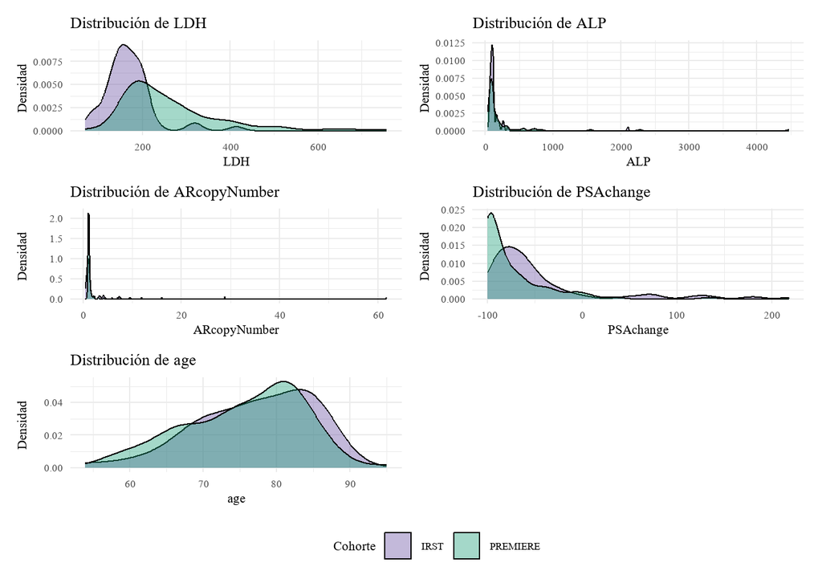

```r
# Unimos los datasets:
df_combinado <- bind_rows(Clinical_data_Spain, Clinical_data_Italy)

# Clasificamos las variables, según como las vamos a tratar en el análisis:
vars_continuas <- c("LDH", "ALP", "ARcopyNumber", "PSAchange", "age")
vars_categoricas <- c("BoneMetsNumber", "Liver", "Lung", "VisceralMets", "Bicalutamide", "LymphNodeMets", "BoneMets", "PSAresponse50", "PSAresponse90", "Event_PFS_PSA", "Event_PFS")

# Gráficas de variables continuas (y la variable entera age):
graficas_continuas <- lapply(vars_continuas, function(v) {
  ggplot(df_combinado, aes_string(x = v, fill = "Cohorte")) +
    geom_density(alpha = 0.4) +
    labs(title = paste("Distribución de", v), x = v, y = "Densidad") +
    theme_minimal() +
    scale_fill_manual(values = colores) +
    theme(text = element_text(family = "Times", size = 16),
          legend.position = "none")
})
# Gráficas de variables categóricas:
graficas_categoricas <- lapply(vars_categoricas, function(v) {
  ggplot(df_combinado, aes_string(x = v, fill = "Cohorte")) +
    geom_bar(position = "fill") +
    labs(title = paste("Dist. de", v), y = "Proporción", x = v) +
    theme_minimal() +
    scale_fill_manual(values = colores) +
    theme(text = element_text(family = "Times", size = 14),
          legend.position = "none")
})

# Usamos una gráfica para extraer y mostrar la leyenda:
leyenda <- ggplot(df_combinado, aes(x = age, fill = Cohorte)) +
  geom_density(alpha = 0.4) +
  theme(legend.position = "bottom") +
  guides(fill = guide_legend(title = "Cohorte"))

# Figura con todos los gráficos de variables continuas (y age):
wrap_plots(graficas_continuas, ncol = 2) +
  plot_layout(guides = "collect") &
  theme(legend.position = "bottom")
```

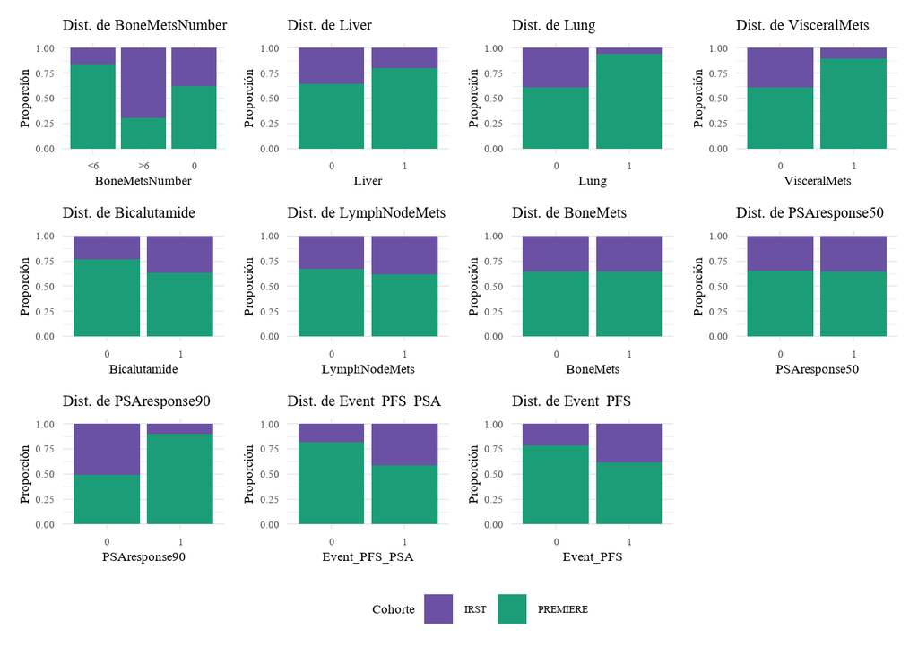

```r
# Figura con todos los gráficos de variables categóricas:
wrap_plots(graficas_categoricas, ncol = 4) +
  plot_layout(guides = "collect") &
  theme(legend.position = "bottom")
```

### Estudio de las relaciones internas entre variables

Graficamos la matriz de correlaciones entre variables numéricas, incluyendo la variable objetivo.

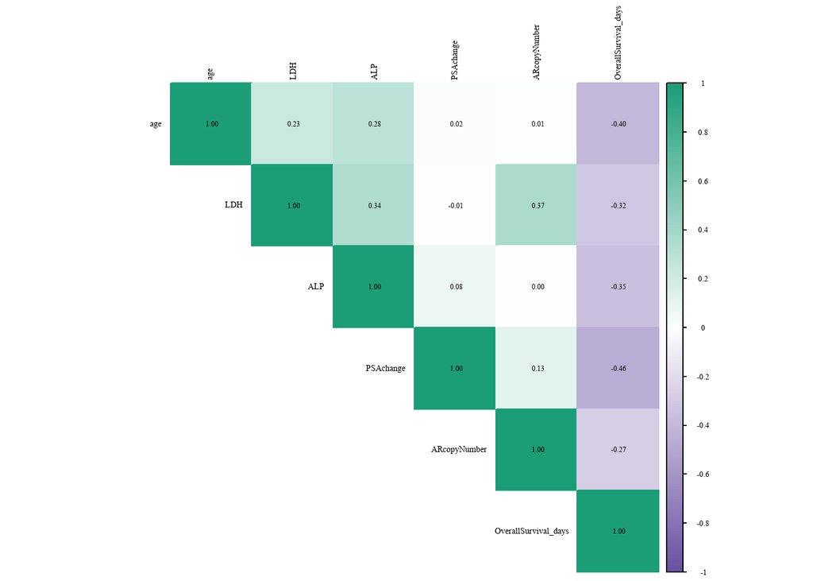

```r
numericas_spain <- Clinical_data_Spain %>% select_if(is.numeric)
cor_mat <- cor(numericas_spain, use = "complete.obs", method = "pearson")
colores_corrplot <- colorRampPalette(c("#6A51A3", "#FFFFFF", "#1B9E77"))(200)
par(family = "Times")
corrplot(cor_mat, method = "color", col = colores_corrplot, type = "upper",
         tl.cex = 0.9, tl.col = "black", addCoef.col = "black", number.cex = 0.75)
```

Realizamos ests entre pares de variables y estudiamos la relación de cada predictor con la variable objetivo.

```r
# Identificamos los tipos de variables:
df  <- Clinical_data_Spain
cat_vars <- names(Filter(is.factor, df))
cat_vars <- setdiff(cat_vars, "Death")
num_vars <- names(Filter(is.numeric, df))
num_vars <- setdiff(num_vars, "OverallSurvival_days")
```

```r
# Contraste Xi-cuadrado para cada par de variables categóricas:
comb_cat <- t(combn(cat_vars, 2))
chi_list <- apply(comb_cat, 1, \(x){
  tab <- table(df[[x[1]]], df[[x[2]]])
  if (all(dim(tab) > 1)) {
    test <- chisq.test(tab, simulate.p.value = TRUE)
    data.frame(var1 = x[1],
               var2 = x[2],
               p    = test$p.value)
  }
})
chi_df <- bind_rows(chi_list) %>% arrange(p)

# Mostramos los resultados:
print("χ² significativos (p < 0.05):")
```

```
## [1] "χ² significativos (p < 0.05):"
```

```r
print(filter(chi_df, p < 0.05))
```

```
##              var1           var2            p
## 1        BoneMets BoneMetsNumber 0.0004997501
## 2    VisceralMets           Lung 0.0004997501
## 3   PSAresponse50  PSAresponse90 0.0004997501
## 4   Event_PFS_PSA      Event_PFS 0.0004997501
## 5   PSAresponse90      Event_PFS 0.0014992504
## 6    VisceralMets          Liver 0.0019990005
## 7   PSAresponse90  Event_PFS_PSA 0.0079960020
## 8           Liver           Lung 0.0129935032
## 9        BoneMets  LymphNodeMets 0.0139930035
## 10 BoneMetsNumber  LymphNodeMets 0.0164917541
```

Boxplots entre variables numéricas y categóricas.

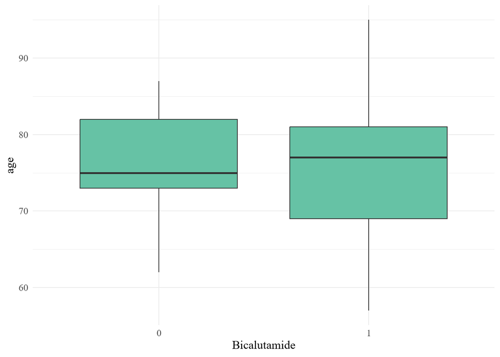

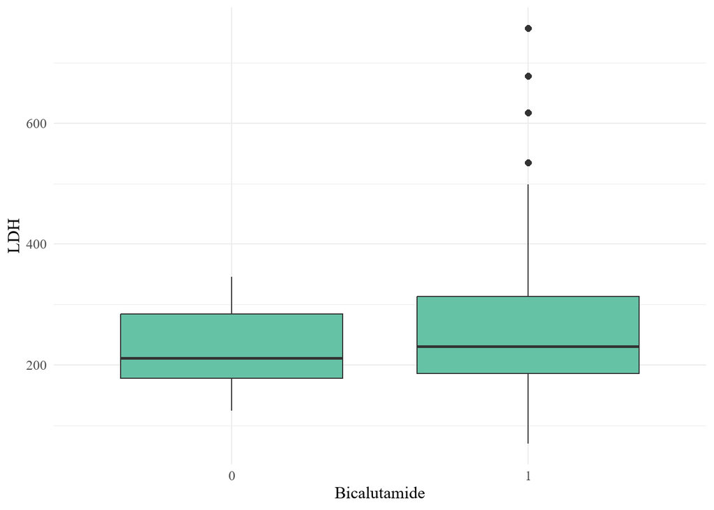

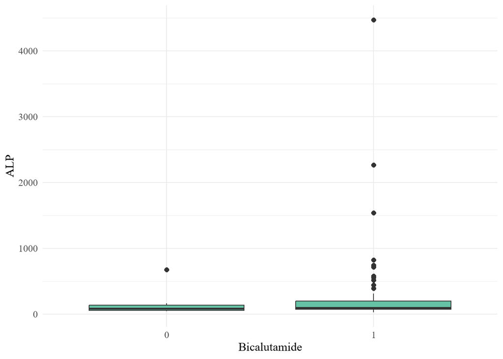

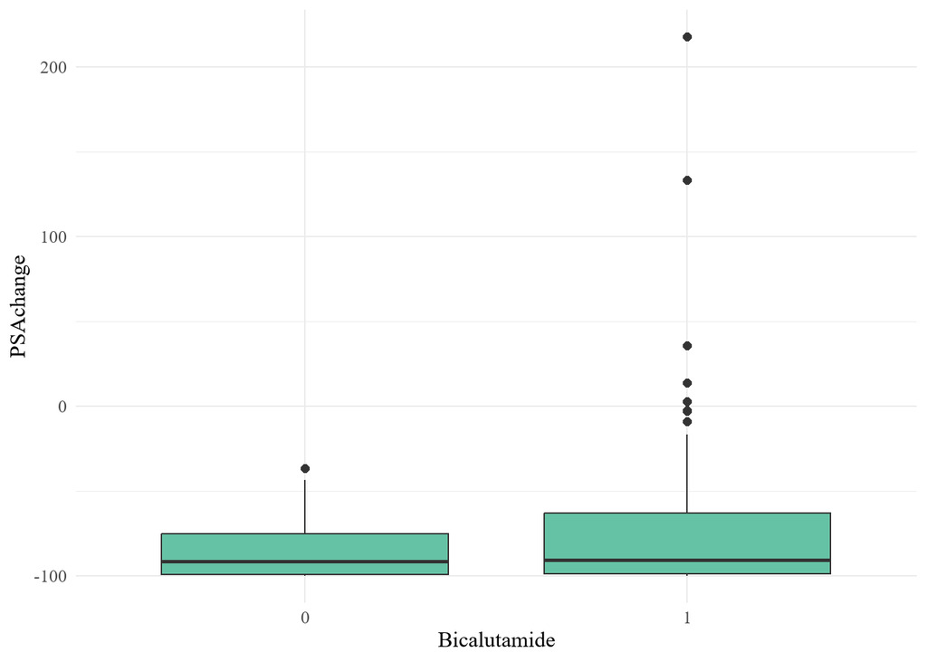

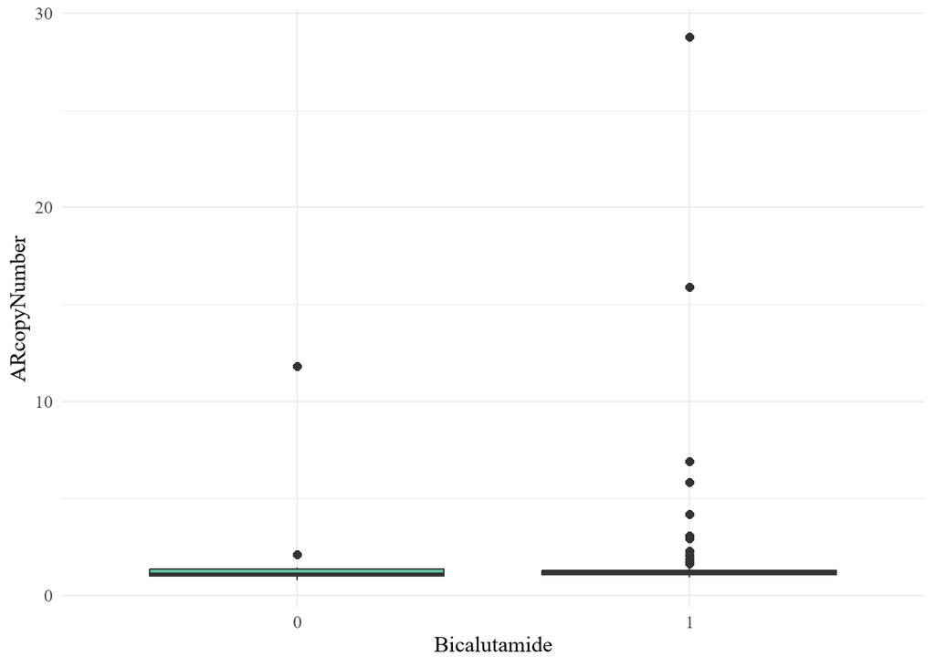

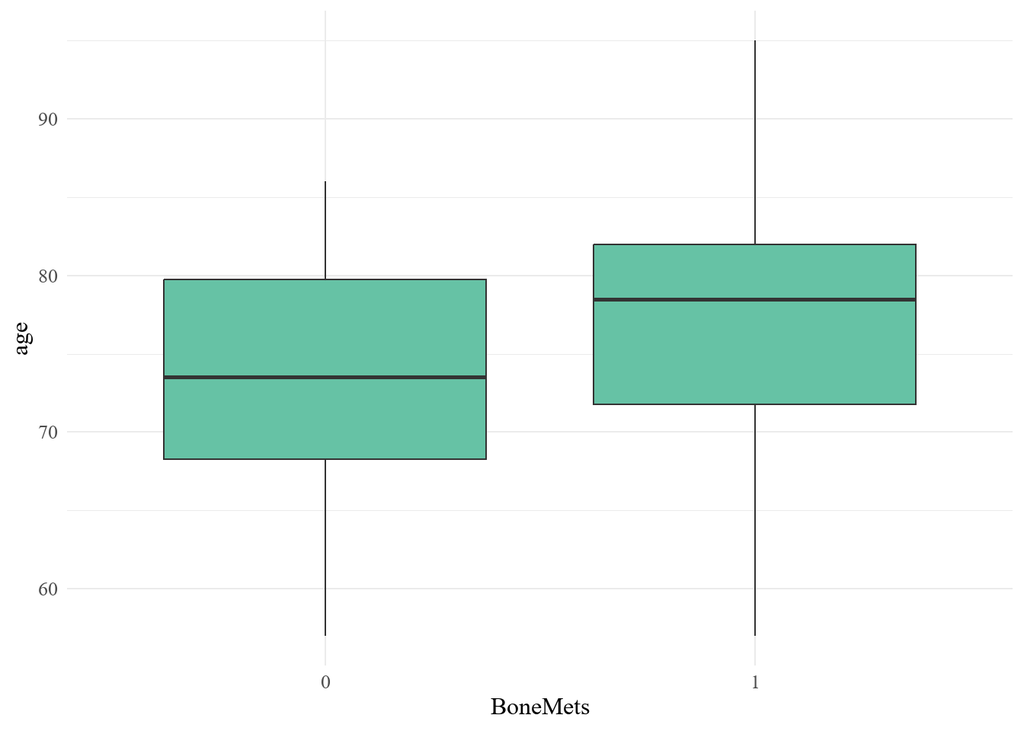

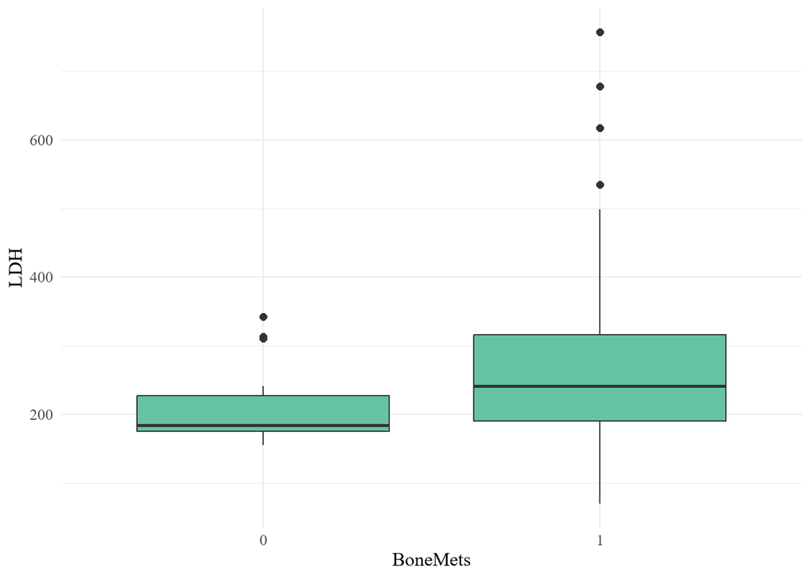

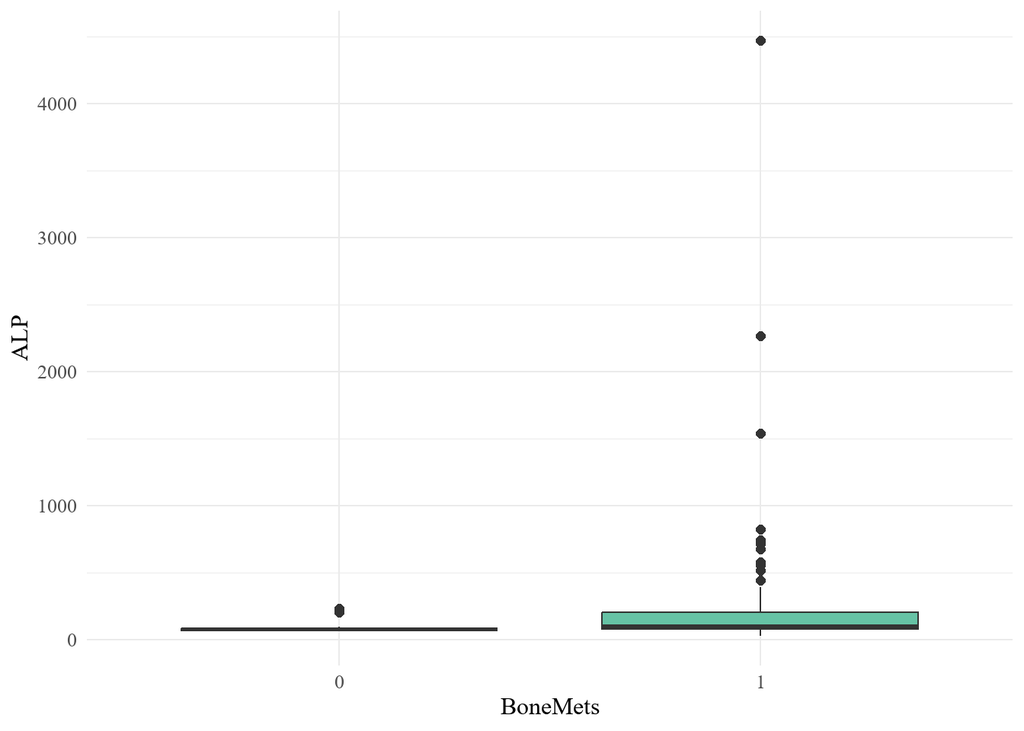

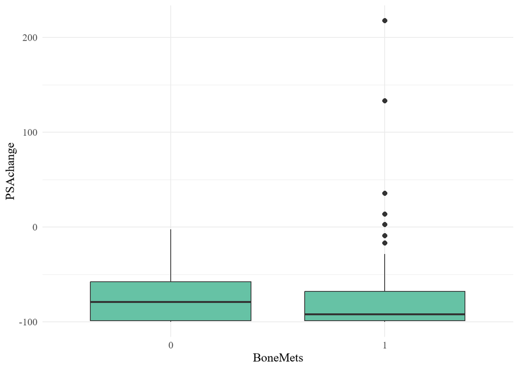

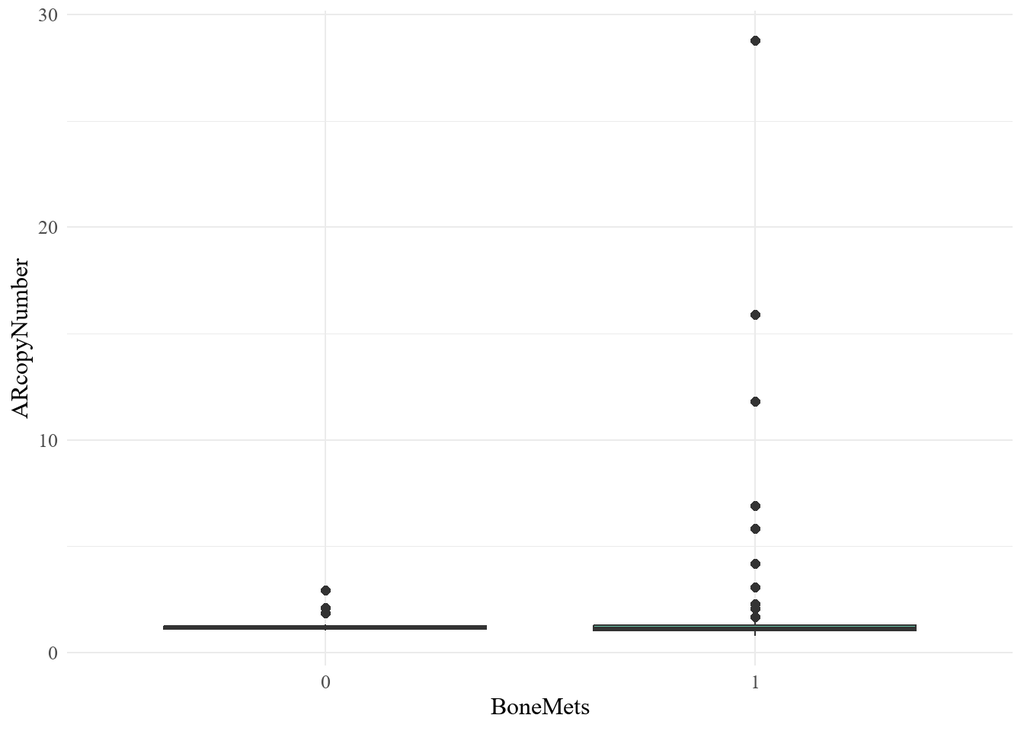

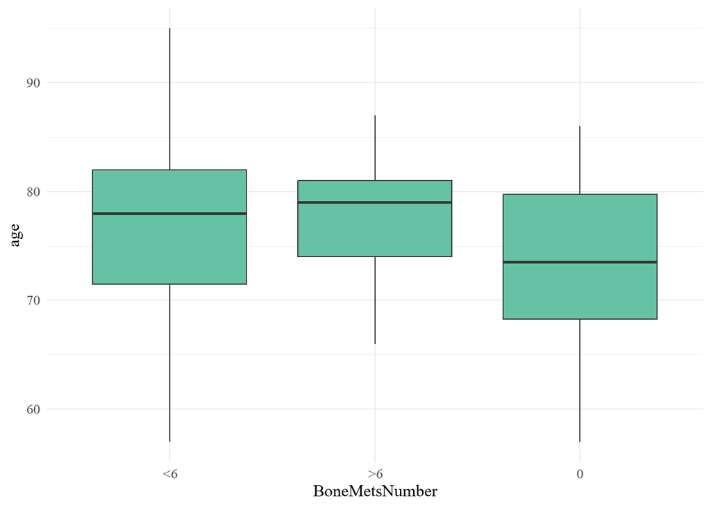

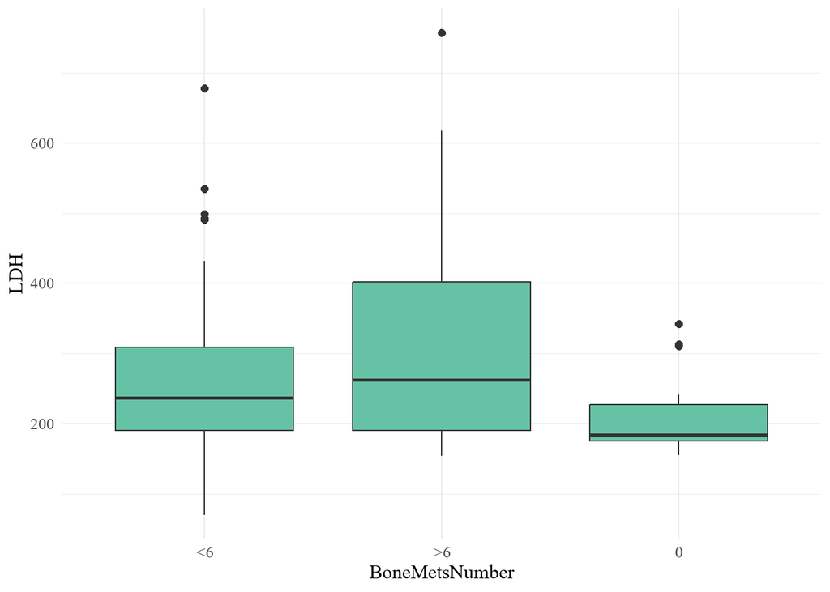

[43 more figures not shown]

```r
# Generar boxplots de cada variable numérica frente a cada categórica
for (cat_var in cat_vars) {
  for (num_var in num_vars) {
    p <- ggplot(df, aes_string(x = cat_var, y = num_var)) +
    geom_boxplot(fill = "#66C2A5", outlier.shape = 16, outlier.size = 2) +
    labs(
      x = cat_var,
      y = num_var
    ) +
    theme_minimal() +
    theme(
      text = element_text(family = "Times", size = 24),
    )

    print(p)
  }
}
```

```r
# Cox univariante para variables numéricas:
num_cox_results <- lapply(num_vars, function(v) {
  formula <- as.formula(paste("Surv(OverallSurvival_days, Death == 1) ~", v))
  model <- coxph(formula, data = df)
  ci <- confint(model)
  summary_model <- summary(model)

  data.frame(
    variable = v,
    HR       = exp(coef(model)),
    CI_low   = exp(ci[1]),
    CI_high  = exp(ci[2]),
    p_value  = summary_model$coefficients[, "Pr(>|z|)"]
  )
}) %>% bind_rows()

# Cox univariante para variables categóricas:
cat_cox_results <- lapply(cat_vars, function(v) {
  formula <- as.formula(paste("Surv(OverallSurvival_days, Death == 1) ~", v))
  model <- coxph(formula, data = df)
  summary_model <- summary(model)
  ci <- confint(model)

  # HR (hazard-rate y CI (intervalo de confianza) de la primera categoría de comparación:
  data.frame(
    variable = v,
    HR       = exp(summary_model$coef[1, "coef"]),
    CI_low   = exp(ci[1, 1]),
    CI_high  = exp(ci[1, 2]),
    p_value  = summary_model$coef[1, "Pr(>|z|)"]
  )
}) %>% bind_rows()

# Unir resultados
cox_all <- bind_rows(num_cox_results, cat_cox_results)

# Ordenar por p-valor
cox_all_sorted <- arrange(cox_all, p_value)

# Mostrar
print(cox_all_sorted)
```

```
##                    variable        HR    CI_low    CI_high      p_value
## PSAchange         PSAchange 1.0137178 1.0083699  1.0190940 4.453983e-07
## LDH                     LDH 1.0047552 1.0025874  1.0069277 1.670428e-05
## ...3          PSAresponse90 0.2963860 0.1654456  0.5309580 4.347517e-05
## ARcopyNumber   ARcopyNumber 1.1143212 1.0518858  1.1804626 2.337917e-04
## ALP                     ALP 1.0005145 1.0001615  1.0008678 4.284865e-03
## ...6          PSAresponse50 0.3881609 0.2015221  0.7476544 4.662368e-03
## age                     age 1.0591325 1.0154492  1.1046951 7.509229e-03
## ...8              Event_PFS 3.6668649 1.3178003 10.2032897 1.282868e-02
## ...9          Event_PFS_PSA 1.6310707 0.8346332  3.1874977 1.523802e-01
## ...10              BoneMets 1.7765799 0.7983745  3.9533278 1.590725e-01
## ...11        BoneMetsNumber 1.4196535 0.6553079  3.0755251 3.743204e-01
## ...12          VisceralMets 1.3437802 0.6509639  2.7739561 4.242602e-01
## ...13          Bicalutamide 1.3768489 0.5459863  3.4720890 4.979984e-01
## ...14         LymphNodeMets 0.8471688 0.4855895  1.4779870 5.591560e-01
## ...15                  Lung 1.2146358 0.5687838  2.5938502 6.154480e-01
## ...16                 Liver 1.2744541 0.3083481  5.2675309 7.376534e-01
```

Eliminamos algunasvariables para evitar redundancias.

```r
Clinical_data_Spain <- Clinical_data_Spain[,!(names(Clinical_data_Spain) %in% c("Cohorte", "BoneMets", "LymphNodeMets", "Lung", "Liver", "Event_PFS_PSA","PSAresponse50","PSAresponse90"))]
Clinical_data_Italy <- Clinical_data_Italy[,!(names(Clinical_data_Italy) %in% c("Cohorte", "BoneMets", "LymphNodeMets", "Lung", "Liver", "Event_PFS_PSA","PSAresponse50","PSAresponse90"))]
```

### Escalado

```r
# Columnas numéricas a escalar:
num_vars <- c("LDH", "ALP", "PSAchange", "age", "ARcopyNumber")

# Escalamos las variables clínicas uniformemente (mismo escalado para ambos datasets):
scaled_means <- sapply(Clinical_data_Spain[, num_vars], mean, na.rm = TRUE)
scaled_sds   <- sapply(Clinical_data_Spain[, num_vars], sd, na.rm = TRUE)

Clinical_data_Spain[, num_vars] <- scale(Clinical_data_Spain[, num_vars],
                                         center = scaled_means,
                                         scale = scaled_sds)

Clinical_data_Italy[, num_vars] <- scale(Clinical_data_Italy[, num_vars],
                                         center = scaled_means,
                                         scale = scaled_sds)
```

# Carga y preprocesamiento de los datos de expresión génica

```r
# Cargamos los datos de expresión a partir de un archivo de texto descargado desde Google Drive:
Expr_data <- read.table("https://drive.google.com/uc?export=download&id=1tdERrRp63nzii2lP0O8PzdzxHA-pqt9z")

# Eliminamos la primera columna, que contiene identificadores (de los genes) no necesarios:
Expr_data[,1] <- NULL

# Utilizamos los nombres de los genes, almacenados en la columna SYMBOL, como nombre de las filas en Expr_data:
row.names(Expr_data) <- Expr_data$SYMBOL

# Reemplazamos los guiones "-" en los nombres de los genes por puntos "." (estaban generando problemas):
rownames(Expr_data) <- gsub("-",".",rownames(Expr_data))

# Filtramos los datos correspondientes a la información de los genes y los 5 controles que no nos interesan. Esto es,
# seleccionamos las 95 primeras columnas, que corresponden a los pacientes de la cohorte española:
Expr_data <- Expr_data[, 1:95]
# NOTA: Hay tres pacientes que aparecen en los datos clínicos pero no en los de expresión: P8, P12 y P21.

# Transponemos el dataset, poniendo genes como columnas y muestras (pacientes) como filas:
Expr_data <- data.frame(t(Expr_data))
```

```r
# Cargamos los datos de expresión a partir de un archivo de texto descargado desde Google Drive:
Expr_data_it <- read.table("https://drive.google.com/uc?export=download&id=1xv0KDaOQ7zF8JynNsFpMQNXzGJn2dB__", sep = "\t", header = T)

# Eliminamos la primera columna, que contiene identificadores (de los genes) no necesarios:
Expr_data_it[,1] <- NULL

# Utilizamos los nombres de los genes, almacenados en la columna SYMBOL, como nombre de las filas en Expr_data:
row.names(Expr_data_it) <- Expr_data_it$SYMBOL

# Reemplazamos los guiones "-" en los nombres de los genes por puntos "." (estaban generando problemas):
rownames(Expr_data_it) <- gsub("-",".",rownames(Expr_data_it))

# Filtramos los datos correspondientes a la información de los genes. Esto es,
# seleccionamos las 54 primeras columnas, que corresponden a los pacientes de la cohorte italiana:
Expr_data_it <- Expr_data_it[, 1:54]

# Transponemos la matriz, poniendo genes como columnas y muestras (pacientes) como filas:
Expr_data_it <- data.frame(t(Expr_data_it))
```

## Creación de los conjuntos de training y test completos (uniendo datos ómicos y clínicos)

```r
# Para poder unir los datos clínicos con los datos de expresión génica, debemos ordenar estos últimos por el
# código del paciente. Posteriormente, creamos una nueva columna con los nombres de las filas (BiobankCode),
# que utilizaremos para realizar la unión:
Expr_data <- Expr_data[order(row.names(Expr_data)),]
Expr_data$BiobankCode <- rownames(Expr_data)

# Creamos el conjunto de entrenamiento con los datos clínicos y los datos genómicos:
# (all=F indica que solo se mantendrán las muestras que están en ambas tablas; esto es, que se realiza un inner join).
Training_completo <- merge(Clinical_data_Spain, Expr_data, by='BiobankCode', all=F)

# Para poder unir los datos clínicos con los datos de expresión génica, debemos ordenar estos últimos por el
# código del paciente. Posteriormente, creamos una nueva columna con los nombres de las filas (BiobankCode),
# que utilizaremos para realizar la unión:
Expr_data_it <- Expr_data_it[order(row.names(Expr_data_it)),]
Expr_data_it$BiobankCode <- rownames(Expr_data_it)

# Creamos el conjunto de entrenamiento con los datos clínicos y los datos genómicos:
# (all=F indica que solo se mantendrán las muestras que están en ambas tablas; esto es, que se realiza un inner join).
Test_completo <- merge(Clinical_data_Italy, Expr_data_it, by='BiobankCode', all=F)
```

## Escalado

```r
# Escalamos las variables ómicas uniformemente (mismo escalado para ambos datasets):
scaled_means <- sapply(Expr_data[,-ncol(Expr_data)], mean, na.rm = TRUE)
scaled_sds   <- sapply(Expr_data[,-ncol(Expr_data)], sd, na.rm = TRUE)

Expr_data[,-ncol(Expr_data)] <- scale(Expr_data[,-ncol(Expr_data)], center = scaled_means, scale = scaled_sds)
Expr_data_it[,-ncol(Expr_data_it)] <- scale(Expr_data_it[,-ncol(Expr_data_it)], center = scaled_means, scale = scaled_sds)
```

## Divergencia de Kullback-Leibler

Vamos a crear varias funciones para calcular la divergencia de Kullback-Leibler (KL) simétrica entre las distribuciones de las variables en dos dataframes. Definimos una función para calcular la divergencia en el caso de distribuciones discretas, y otra para distribuciones continuas. Asimismo, añadimos una función para calcular la Divergencia de Jensen-Shannon (JS) entre distribuciones, una medida de similitud entre distribuciones de probabilidad basada en la divergencia de Kullback-Leibler (KL), pero más simétrica y estable numéricamente.

### Divergencia KL para distribuciones discretas

```r
# Función para calcular la divergencia KL simétrica entre las distribuciones de las variables (genes)
# de dos dataframes (de datos de expresión génica), discretizando primero dichas distribuciones. Sus argumentos son:
#   df1: Primer dataframe con datos de expresión génica.
#   df2: Segundo dataframe con datos de expresión génica.
#   numBins: Número de bins para discretizar los datos (por defecto, 5).
KLgenedf_opt <- function(df1, df2, numBins = 5) {

  # Obtenemos los nombres de las columnas de df1, que asumimos que coinciden con los de df2:
  df1names <- colnames(df1)

  # Aseguramos que ambos dataframes tienen las mismas columnas (genes) y en el mismo orden:
  df1 <- df1[, df1names]
  df2 <- df2[, df1names]

  # Creamos un dataframe para almacenar los resultados, con una fila de ceros y tantas columnas como genes:
  dfkldif <- data.frame(matrix(0, nrow = 1, ncol = length(df1names),
                                dimnames = list(NULL, df1names)))

  # Función interna para calcular la divergencia KL entre las distribuciones discretizadas cada gen (columna):
  compute_kldif <- function(gene) {

    # Obtenemos los rangos de expresión del gen en los dos datasets:
    df1range <- range(df1[, gene])
    df2range <- range(df2[, gene])

    # Determinamos el rango común de expresión entre ambos datasets; esto es, el rango mínimo y máximo compartido.
    # Esto garantiza que ambos datasets sean comparables dentro del mismo intervalo al discretizar las distribuciones.
    ourrange <- c(min(df1range[1], df2range[1]), max(df1range[2], df2range[2]))

    if(length(ourrange) != 2 || any(is.na(ourrange)) || any(!is.finite(ourrange))) {
      print(gene)
      print(ourrange)
      #stop("Error: ourrange no es válido. Revisar datos de entrada.")
    }

    # Discretizamos la distribución de expresión génica en bins. Es decir, dividimos la distribución de expresión
    # del gen en numBins segmentos dentro del rango ourrange.
    disdf1 <- discretize(df1[, gene], numBins = numBins, r = ourrange)
    disdf2 <- discretize(df2[, gene], numBins = numBins, r = ourrange)

    # Calculamos las probabilidades de ambas distribuciones:
    pdisdf1 <- disdf1 / sum(disdf1)
    pdisdf2 <- disdf2 / sum(disdf2)

    # Calculamos la divergencia KL simétrica:
    kldif <- KL.plugin(pdisdf1, pdisdf2) + KL.plugin(pdisdf2, pdisdf1)

    return(kldif)
  }

  # Aplicamos la función compute_kldif a cada gen de df1names:
  dfkldif[] <- lapply(df1names, compute_kldif)

  return(dfkldif)
}
```

### Divergencia KL para distribuciones continuas

```r
# Función para calcular la divergencia KL simétrica entre las distribuciones (continuas) de las variables (genes)
# de dos dataframes (de datos de expresión génica). Sus argumentos son:
#   df1: Primer dataframe con datos de expresión génica.
#   df2: Segundo dataframe con datos de expresión génica.
#   bw: ancho de banda del kernel para la estimación de la densidad (por defecto, "nrd0").
KLgenedf_opt_continuous <- function(df1, df2, bw = "nrd0") {

  # Función interna para calcular la divergencia KL continua entre dos distribuciones de probabilidad:
  kl_cont <- function(p,q){
      aux <- unique(ifelse((p > 0 & q == 0), Inf, # si p > 0 y q == 0, se asigna infinito.
                           sum(ifelse(p != 0 & q != 0, p * log(p/q), 0)))) # si p y q son no nulos, se usa la fórmula de KL.
      if(length(aux)>1){return(Inf)}else{return(aux)}
      }

  # Obtenemos los nombres de las columnas (genes), que se asumen iguales para ambos datasets:
  df1names <- colnames(df1)

  # Aseguramos que ambos dataframes tengan las mismas columnas y en el mismo orden:
  df1 <- df1[, df1names]
  df2 <- df2[, df1names]

  # Creamos un dataframe para almacenar los resultados:
  dfkldif <- data.frame(matrix(0, nrow = 1, ncol = length(df1names),
                                dimnames = list(NULL, df1names)))

  # Función interna para calcular la divergencia KL entre las distribuciones (continuas) de cada gen:
  compute_kldif <- function(gene) {

    # Extraemos los datos de expresión del gen concreto:
    df1_gene <- df1[, gene]
    df2_gene <- df2[, gene]

    # Obtenemos el rango (mínimo y máximo) compartido entre ambos datasets:
    ourrange <- range(c(df1_gene, df2_gene))

    # Determinamos el ancho de banda (bw) para la estimación de densidad de cada dataset.
    # Si se proporciona un valor fijo de bw, lo utiliza en lugar de calcularlo:
    bw1 <- if (bw == "nrd0") { dpik(df1_gene) } else { bw }
    bw2 <- if (bw == "nrd0") { dpik(df2_gene) } else { bw }

    # Calculamos la densidad de probabilidad estimada con KDE (Kernel Density Estimation) par el gen
    # en el dataset. Debemos tener en cuenta tres cosas:
    #   1. density() estima la función de densidad de probabilidad usando un kernel gaussiano.
    #   2. Para asegurar que ambas densidades se calculen en el mismo intervalo, utilizamos el rango
    #      compartido (ourrange).
    #   3. n = número de puntos en los que se calcula la densidad (1000).
    kde1 <- density(df1_gene, bw = bw1, from = ourrange[1], to = ourrange[2], n = 1500)
    kde2 <- density(df2_gene, bw = bw2, from = ourrange[1], to = ourrange[2], n = 1500)
    # Nota: Ambas distribuciones se evalúan en los mismos 1000 puntos.

    # Calculamos las probabilidades de ambas distribuciones:
    pdf1 <- kde1$y / sum(kde1$y)
    pdf2 <- kde2$y / sum(kde2$y)

    # Calculamos la divergencia KL simétrica:
    kldif1 <- kl_cont(pdf1,pdf2)
    kldif2 <- kl_cont(pdf2,pdf1)
    kldif <- kldif1 + kldif2

    return(kldif)
  }

  # Aplicamos compute_kldif a todos los genes:
  dfkldif[] <- lapply(df1names, compute_kldif)

  return(dfkldif)}
```

### Divergencia JS

```r
# Función para calcular la divergencia de Jensen-Shannon (JS) entre dos conjuntos de datos de expresión génica. Sus
# argumentos son:
#     df1 y df2: dataframes con los valores de expresión génica de dos conjuntos de muestras.
#     bw: ancho de banda para la estimación de densidad con kernel (KDE) (por defecto, se tiene "nrd0", que usa una
#         estimación óptima con dpik().
JSgenedf_opt_continuous <- function(df1, df2, bw = "nrd0") {

    # Función interna para calcular la divergencia KL entre dos distribuciones continuas:
    kl_cont <- function(p,q){
        aux <- unique(ifelse((p > 0 & q == 0),
             Inf,
             sum(ifelse(p != 0 & q != 0, p * log(p/q), 0))))
        if(length(aux)>1){return(Inf)}else{return(aux)}
      }

  # Obtenemso los nombres de las columnas (genes):
  df1names <- colnames(df1)

  # Aseguramos que df1 y df2 tienen las mismas columnas en el mismo orden:
  df1 <- df1[, df1names]
  df2 <- df2[, df1names]

  # Creamos un dataframe vacío para almacenar los resultados:
  dfjsdif <- data.frame(matrix(0, nrow = 1, ncol = length(df1names),
                                dimnames = list(NULL, df1names)))

  # Función interna para calcular la divergencia JS entre las distribuciones de expresión de un gen en df1 y df2:
  compute_jsdif <- function(gene) {

    # Extraemos los valores de expresión para el gen en df1 y df2:
    df1_gene <- df1[, gene]
    df2_gene <- df2[, gene]

    # Determinamos el rango compartido de los datos:
    ourrange <- range(c(df1_gene, df2_gene))

    # Calculamos el ancho de banda para la estimación de la densidad con kernel (KDE):
    bw1 <- if (bw == "nrd0") { dpik(df1_gene) } else { bw }
    bw2 <- if (bw == "nrd0") { dpik(df2_gene) } else { bw }

    # Computamos la estimación de las densidades de probabilidad con KDE. Ambas distribuciones se evalúan en los
    # mismos 1000 puntos dentro del rango calculado ourrange:
    kde1 <- density(df1_gene, bw = bw1, from = ourrange[1], to = ourrange[2], n = 1000)
    kde2 <- density(df2_gene, bw = bw2, from = ourrange[1], to = ourrange[2], n = 1000)

    # Calculamos las probabilidades:
    pdf1 <- kde1$y / sum(kde1$y)
    pdf2 <- kde2$y / sum(kde2$y)

    # Calculamos la distribución promedio, que es la base de la divergencia JS:
    mpdf <- (pdf1 + pdf2) / 2

    # Calculamos la divergencia JS usando KL. Para ello, computamos la divergencia KL entre cada distribución
    # (pdf1 y pdf2) y la media (mpdf):
    kl_dif1 <- kl_cont(pdf1,mpdf)
    kl_dif2 <- kl_cont(pdf2,mpdf)

    # La divergencia de Jensen Shannon es la media de las divergencias KL calculadas:
    jsdif <- (kl_dif1 + kl_dif2)/2

    return(jsdif)
  }

  # Aplicamos compute_jsdif a todos los genes:
  dfjsdif[] <- lapply(df1names, compute_jsdif)

  return(dfjsdif)
}
```

### Cómputo de las divergencias

En esta sección, vamos a ejecutar las funciones definidas previamente, para estudiar la similitud en las distribuciones de expresión de todos los genes del dataset. Nuestro objetivo es seleccionar aquellos genes que presenten distribuciones de expresión similares en ambos datasets. Dichos genes serán utilizados como variables predictoras en una posterior aplicación de algoritmos de machine learning para predecir la probabilidad de muerte y el tiempo estimado de supervivencia de los pacientes. Al elegir los genes con distribuciones de expresión similares en las dos cohortes, nos aseguramos de evitar utilizar genes cuya expresión varíe entre pacientes españoles e italianos por motivos distintos a los de la propia enfermedad.

No obstante, antes de calcular las divergencias debemos modificar ligeramente los datos, para evitar errores. Eliminamos las columnas con el código del biobanco (BiobankCode) de ambos datasets:

```r
Expr_data <- Expr_data[, -ncol(Expr_data)]
Expr_data_it <- Expr_data_it[, -ncol(Expr_data_it)]
```

```r
# Calculamos la divergencia KL discretizando las distribuciones de expresión de los genes:
# Genes_KL_Discrete <- t(KLgenedf_opt(Expr_data, Expr_data_it))

# Calculamos la divergencia KL entre las distribuciones de expresión como si fuesen continuas:
# Genes_KL_Continuos <- t(KLgenedf_opt_continuous(Expr_data, Expr_data_it))

# Calculamos la divergencia JS entre las distribuciones de expresión de todos los genes:
Genes_JS <- t(JSgenedf_opt_continuous(Expr_data, Expr_data_it))
```

Queremos los genes con valores de KL y JS más bajos en función de los deciles y cuartiles.

```r
# Función para filtrar genes con base en la divergencia KL, eliminando valores infinitos y seleccionando los genes más similares entre datasets.
# Su único argumento es Genes_KL, un dataframe con los valores de KL para cada gen, que están almacenados en la columna "V1".
KL_quartile_filter <- function(Genes_KL){

  # Convertimos Genes_KL en un dataframe, asegurando que mantiene los nombres de los genes (filas):
  Genes_KL_df <- as.data.frame(Genes_KL, row.names = row.names(Genes_KL))

  # Filtramos solo genes con valores finitos de KL, eliminando aquellos con KL = Inf.
  Genes_finite <- Genes_KL_df[is.finite(Genes_KL_df$V1), , drop = FALSE]

  # Ordenamos los genes por el valor de KL (de menor a mayor):
  Sorted_Genes_finite <- Genes_finite[order(Genes_finite$V1), , drop = FALSE]

  # Filtramos los genes en el primer decil (el 10% con menor KL):
  decile <- quantile(Sorted_Genes_finite$V1, probs = 0.1)
  df_decile <- subset(Sorted_Genes_finite, V1 <= decile)

  # Filtramos los genes del primer y segundo cuartil (25% y 50% con menor KL):
  quartile_Q1 <- quantile(Sorted_Genes_finite$V1, probs = 0.25)
  quartile_Q2 <- quantile(Sorted_Genes_finite$V1, probs = 0.5)
  df_quartile1 <- subset(Sorted_Genes_finite, V1 <= quartile_Q1)
  df_quartile2 <- subset(Sorted_Genes_finite, V1 <= quartile_Q2)

  cat("Valor de corte KL - 1er Decil:", decile, "\n")
  cat("Valor de corte KL - 1er Cuartil:", quartile_Q1, "\n")
  cat("Valor de corte KL - 2do Cuartil:", quartile_Q2, "\n")

  # Devolvemos los genes filtrados y ordenados:
  return(list(df_decile, df_quartile1, df_quartile2,Sorted_Genes_finite ))
}

# Función para filtrar los genes seleccionados por la función anterior:
filter_genes <- function(dataset, filtered_genes) {
  selected_cols <- c("OverallSurvival_days", "Death", filtered_genes)
  return(dataset[, selected_cols])
}
```

En este caso, seleccionamos los genes correspondientes al primer cuartil con divergencia JS.

```r
# Ejecutamos las funciones para nuestros genes:
# Genes_KL_values <- KL_quartile_filter(Genes_KL_Discrete)
# Genes_KL_values_Continuos <- KL_quartile_filter(Genes_KL_Continuos)
Genes_JS_values <- KL_quartile_filter(Genes_JS)
saveRDS(Genes_JS_values, file = "Genes_JS_values.rds")
```

```r
Genes_JS_values <- readRDS("Genes_JS_values.rds")
# Genes elegidos (primer decil, primer cuartil, segundo cuartil y conjunto completo):
Selected_Genes_JS_Filtered_decile <- rownames(Genes_JS_values[[1]])
Selected_Genes_JS_Filtered_1st_quartile <- rownames(Genes_JS_values[[2]])
Selected_Genes_JS_Filtered_2st_quartile <- rownames(Genes_JS_values[[3]])
Selected_Genes_JS_Filtered_all <- rownames(Genes_JS_values[[4]])

# Entrenamiento:
Training_dataset_filtered_JS_Decile <- filter_genes(Training_completo, Selected_Genes_JS_Filtered_decile)
Training_dataset_filtered_JS_1st_quartile <- filter_genes(Training_completo, Selected_Genes_JS_Filtered_1st_quartile)
Training_dataset_filtered_JS_2st_quartile <- filter_genes(Training_completo, Selected_Genes_JS_Filtered_2st_quartile)
Training_dataset_filtered_JS_All <- filter_genes(Training_completo, Selected_Genes_JS_Filtered_all)

# Validación:
Validation_dataset_filtered_JS_Decile <- filter_genes(Test_completo, Selected_Genes_JS_Filtered_decile)
Validation_dataset_filtered_JS_1st_quartile <- filter_genes(Test_completo, Selected_Genes_JS_Filtered_1st_quartile)
Validation_dataset_filtered_JS_2st_quartile <- filter_genes(Test_completo, Selected_Genes_JS_Filtered_2st_quartile)
Validation_dataset_filtered_JS_All <- filter_genes(Test_completo, Selected_Genes_JS_Filtered_all)
```

# Conjuntos de datos de training y test - escenarios

Definimos los 5 escenarios posibles con los genes seleccionados tras la divergencia JS.

```r
# ESCENARIO 1: Clinical before treatment
training_clinical_bt <- Training_completo[,!(names(Training_completo) %in% c("BiobankCode", "Cohorte", "Event_PFS", "PSAchange"))]
training_clinical_bt <- training_clinical_bt[,names(training_clinical_bt) %in% names(Clinical_data_Spain)]

test_clinical_bt <- Test_completo[,!(names(Test_completo) %in% c("BiobankCode", "Cohorte", "Event_PFS", "PSAchange"))]
test_clinical_bt <- test_clinical_bt[,names(test_clinical_bt) %in% names(Clinical_data_Italy)]

saveRDS(training_clinical_bt, "training_clinical_bt.rds")
saveRDS(test_clinical_bt, "test_clinical_bt.rds")

# ESCENARIO 2: Expresión
training_expresion <- Training_dataset_filtered_JS_1st_quartile
training_expresion <- training_expresion[, !(names(training_expresion) %in% c("BiobankCode", "Cohorte"))]
test_expresion <- Validation_dataset_filtered_JS_1st_quartile
test_expresion <- test_expresion[, !(names(test_expresion) %in% c("BiobankCode", "Cohorte"))]

saveRDS(training_expresion, "training_expresion.rds")
saveRDS(test_expresion, "test_expresion.rds")

# ESCENARIO 3: Both before treatment
training_both_bt <- Training_completo[,c(names(training_expresion),names(training_clinical_bt))]
test_both_bt <- Test_completo[,c(names(test_expresion),names(test_clinical_bt))]

saveRDS(training_both_bt, "training_both_bt.rds")
saveRDS(test_both_bt, "test_both_bt.rds")

# ESCENARIO 4: Clinical after treatment
training_clinical_at <- Training_completo[,!(names(Training_completo) %in% c("BiobankCode", "Cohorte"))]
training_clinical_at <- training_clinical_at[,names(training_clinical_at) %in% names(Clinical_data_Spain)]

test_clinical_at <- Test_completo[,!(names(Test_completo) %in% c("BiobankCode", "Cohorte"))]
test_clinical_at <- test_clinical_at[,names(test_clinical_at) %in% names(Clinical_data_Italy)]

saveRDS(training_clinical_at, "training_clinical_at.rds")
saveRDS(test_clinical_at, "test_clinical_at.rds")

# ESCENARIO 5: Both after treatment
training_both_at <- Training_completo[,c(names(training_expresion),names(training_clinical_at))]
test_both_at <- Test_completo[,c(names(test_expresion),names(test_clinical_at))]

saveRDS(training_both_at, "training_both_at.rds")
saveRDS(test_both_at, "test_both_at.rds")
```